# 5) Creating Spelling Groups

2026-06-27

```r
# Load in the package
library(tidyverse)
library(patchwork)
library(sjPlot)
library(nlraa)
library(kableExtra)
```

First 10 rows of the Combined Dataset

| ID | Sex | Age | raw_spell | eap_spell |
| --- | --- | --- | --- | --- |
| 10053 | F | 19 | 38 | 0.5668013 |
| 10510 | M | 17 | 26 | -0.4114403 |
| 10816 | F | 17 | 21 | -0.9072170 |
| 10974 | F | 21 | 40 | 0.8107680 |
| 11646 | F | 16 | 35 | 0.3194469 |
| 11672 | M | 19 | 31 | -0.1150901 |
| 11754 | F | 20 | 35 | 0.2264244 |
| 12152 | F | 18 | 40 | 1.3743487 |
| 12289 | M | 16 | 31 | -0.0193717 |
| 12534 | M | 28 | 25 | -0.5035214 |

### Viewing the Distribution of Scores by Spelling Group

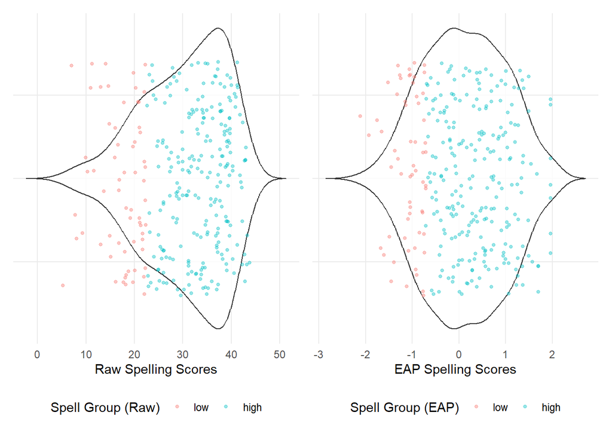

Group Endorsement by Spelling Score Approach Contingency Table

| Spell_Group_Raw | Spell_Group_EAP |  | Total |  |
| --- | --- | --- | --- | --- |
|  | low | high |  |  |
| low | 58 90.6 % | 6 9.4 % |  | 64 100 % |
| high | 3 1.3 % | 236 98.7 % | 239 100 % |  |
| Total | 61 20.1 % | 242 79.9 % | 303 100 % |  |

### Age Confounded with Spelling Performance

Here we see a notable problem, and that’s that most poor spellers are younger people in the sample, while in the older ages (25+ years), there are very few poor spellers. This will essentially be problematic for us in the subsequent EEG analysis and needs to be addressed.

However, due to the dots overlapping each other in the figure, we are limited to know just by how much the disparities between good and poor spellers are across the ages.

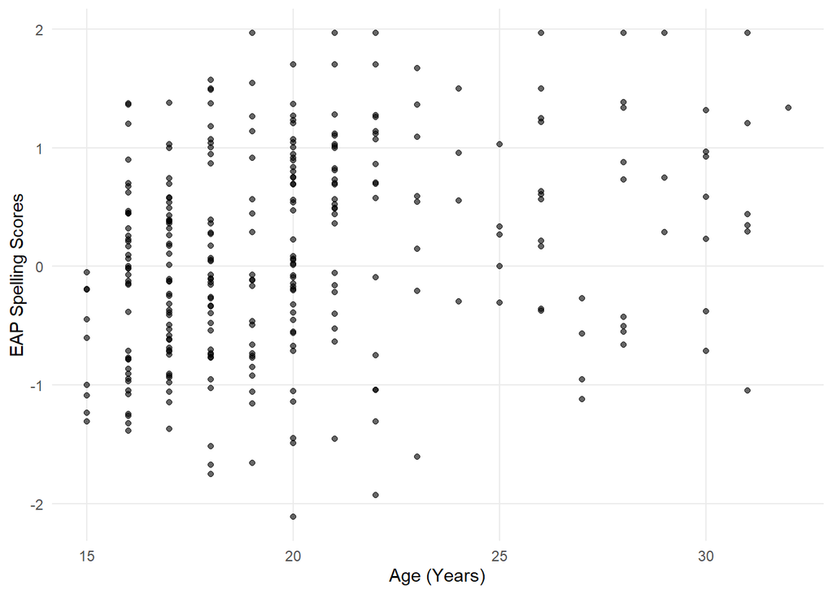

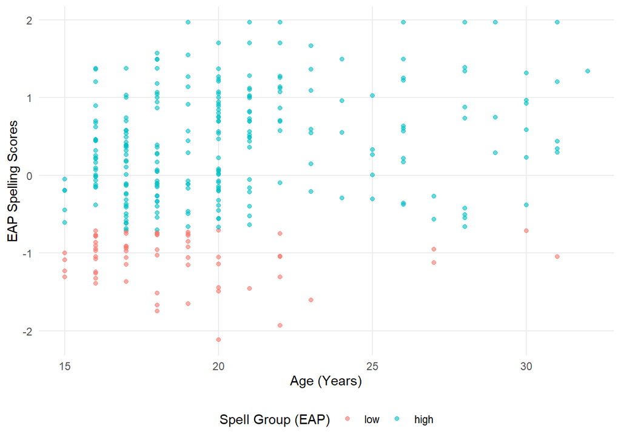

```
15-17 17-18 18-20 20-22 22-32
   95    40    67    43    58
```

```
15-17 17-18 18-20 20-22 22-32
 0.31  0.13  0.22  0.14  0.19
```

Good vs Poor Spellers Across Age Groups Contingency Table

| Age_group | Spell_Group_EAP |  | Total |  |
| --- | --- | --- | --- | --- |
|  | low | high |  |  |
| 15-17 | 27 28.4 % | 68 71.6 % |  | 95 100 % |
| 17-18 | 9 22.5 % | 31 77.5 % | 40 100 % |  |
| 18-20 | 14 20.9 % | 53 79.1 % | 67 100 % |  |
| 20-22 | 6 14 % | 37 86 % | 43 100 % |  |
| 22-32 | 5 8.6 % | 53 91.4 % | 58 100 % |  |
| Total | 61 20.1 % | 242 79.9 % | 303 100 % |  |

### Using a Quadratic to Plateau Model to Control for Age Effects on Spelling Performance

Below we are introducing the quadratic to plateau (QTP) model, which is a **non-linear model**. To fit this, we are using the `nls()` function which allows non-linear model specification in conjunction with the `SSquadp3xs()` help function. The latter is from the nlraa package and it is a self starter function, meaning that it takes care in picking the reasonable starting values for the QTP so we don’t have to.

The equation itself is a bit tricky, but the main idea are as follows:

1. There is a quadratic relationship between x and y up until a certain point in x
2. At a specific value of x, the relationship turns into a plateau, meaning for every change in x, y stays the same
3. The transition point is the same as the peak of a parabola in a regular quadratic function
4. The model parameter estimates are the: intercept, instantaneous slope, join point (quadratic is not **freely estimated**)
5. Essentially, this model requires the same degrees of freedom as a quadratic model (three parameters are estimated)

Anyway, we basically fit the QTP model to the EAP scores using age as a predictor. We use the model parameters to generate fitted values. We subtract the EAP scores by the fitted values to get the model residuals, and then we classify the bottom 20th percentile residuals as low and the remaining 80% as high. Essentially, what we have done now is change the scoring to represent good and poor spellers for their respective age groups.

### Unexpected Problem

When we run a QTP model using nls() and SSquadp3xs(), we get the error of a **singular gradient**. Which basically means the model is stuck and cannot find the best parameter values to best represent the data.

```r
try(
# run a quadratic to plateau regression
spell.nls <- nls(eap_spell ~ SSquadp3xs(Age, a, b, jp),
                 data = comb_dat)
)
```

```
Error in nls(eap_spell ~ SSquadp3xs(Age, a, b, jp), data = comb_dat) :
  singular gradient
```

We can get a hint to what the problem is below using the getInitial() function. Essentially. SSquadp3xs has identified the best starting values to be: a = -1.94; b = 0.13; c = 46.0. We can see that from these values there is a clear problem, specifically with the join point estimate, it is substantially larger than our max age value in our data. Thus, the starting values chosen are essentially preventing the model from functioning correctly.

```r
# What were the chosen starting values
getInitial(
  eap_spell ~ SSquadp3xs(Age, a, b, jp),
  data = comb_dat
)
```

```
         a          b         jp
-1.9418435  0.1295633 45.9599296
```

### Choosing our Own Starting Values

```r
# Specify a model with chosen starting values
spell.nls <- nls(
  eap_spell ~ ifelse(
    Age < jp,
    a + b*Age - 0.5*b*Age^2/jp,
    a + 0.5*b*jp
  ),
  data = comb_dat,
  start = list(a = -1, b = 0.2, jp = 18)
)
```

### Additional Starting Values Because Why Not?

This will be a good learning purpose, essentially, we are going to just mess with the join point, and run the model several times a fixed intercept and slope and a different joint points value. Then we will see which join point values led to a convergence followed by what the parameter estimates look like.

Joint Point Starting Values that Resulted in Model Convergence

| iteration | start_jp | a | b | jp |
| --- | --- | --- | --- | --- |
| 17 | 17 | -4.645039 | 0.3988015 | 25.67892 |
| 18 | 18 | -4.645299 | 0.3988279 | 25.67846 |
| 23 | 23 | -4.645065 | 0.3988041 | 25.67887 |
| 24 | 24 | -4.644968 | 0.3987943 | 25.67904 |
| 25 | 25 | -4.645015 | 0.3987991 | 25.67896 |
| 26 | 26 | -4.644942 | 0.3987917 | 25.67909 |
| 27 | 27 | -4.645168 | 0.3988146 | 25.67869 |
| 28 | 28 | -4.644945 | 0.3987920 | 25.67908 |
| 29 | 29 | -4.645069 | 0.3988045 | 25.67887 |
| 30 | 30 | -4.645055 | 0.3988031 | 25.67889 |
| 31 | 31 | -4.645054 | 0.3988030 | 25.67889 |
| 32 | 32 | -4.645200 | 0.3988178 | 25.67864 |

### Building A Function to Find Good Starting Values (Proof of Concept)

This code here is just to prove that we can create a function to identify the best starting values to get a converged QTP. I really have no idea how this code works, it was provided by ChatGPT. Regardless, the implication here is that we can learn the details of this function, and then modify it to then make it work with our QTpME models if they failed to start due to a singularity error!

```r
fit_qtp <- function(data,
                    a_vals = seq(-3, 1, by = 0.5),
                    b_vals = seq(0.05, 0.5, by = 0.05),
                    jp_vals = seq(18, 28, by = 1)) {

  starts <- expand.grid(
    a = a_vals,
    b = b_vals,
    jp = jp_vals
  )

  for(i in seq_len(nrow(starts))) {

    s <- as.list(starts[i, ])

    fit <- try(
      nls(
        eap_spell ~ ifelse(
          Age < jp,
          a + b*Age - 0.5*b*Age^2/jp,
          a + 0.5*b*jp
        ),
        data = data,
        start = s
      ),
      silent = TRUE
    )

    if(!inherits(fit, "try-error")) {
      message("Successful fit!")
      print(s)
      return(fit)
    }
  }

  stop("No starting values converged.")
}
```

In this output we can see the starting values that led to model convergence from the custom function output.

```r
# Fitting a QTP model with functioning starting values
spell.nls <- fit_qtp(comb_dat)
```

```
$a
[1] -0.5

$b
[1] 0.05

$jp
[1] 18

attr(,"out.attrs")
attr(,"out.attrs")$dim
 a  b jp
 9 10 11

attr(,"out.attrs")$dimnames
attr(,"out.attrs")$dimnames$a
[1] "a=-3.0" "a=-2.5" "a=-2.0" "a=-1.5" "a=-1.0" "a=-0.5" "a= 0.0" "a= 0.5" "a= 1.0"

attr(,"out.attrs")$dimnames$b
 [1] "b=0.05" "b=0.10" "b=0.15" "b=0.20" "b=0.25" "b=0.30" "b=0.35" "b=0.40" "b=0.45" "b=0.50"

attr(,"out.attrs")$dimnames$jp
 [1] "jp=18" "jp=19" "jp=20" "jp=21" "jp=22" "jp=23" "jp=24" "jp=25" "jp=26" "jp=27" "jp=28"
```

Below is the model summary of the QTP- we can see that it came out okay!

```
Formula: eap_spell ~ ifelse(Age < jp, a + b * Age - 0.5 * b * Age^2/jp,
    a + 0.5 * b * jp)

Parameters:
   Estimate Std. Error t value Pr(>|t|)
a   -4.6450     2.0494  -2.267   0.0241 *
b    0.3988     0.2017   1.977   0.0489 *
jp  25.6789     3.2527   7.895 5.52e-14 ***
---
Signif. codes:  0 '***' 0.001 '**' 0.01 '*' 0.05 '.' 0.1 ' ' 1

Residual standard error: 0.8301 on 300 degrees of freedom

Number of iterations to convergence: 11
Achieved convergence tolerance: 2.524e-06
```

### Rescore the Spelling Groups Using the QTP Residuals

Now we will rescore the data by getting the residuals from the QTP model, and specifying those at the bottom 20th percentile as the poor spellers. The interpretation of these values will not change to mean poor spellers compared to those of their same age peers.

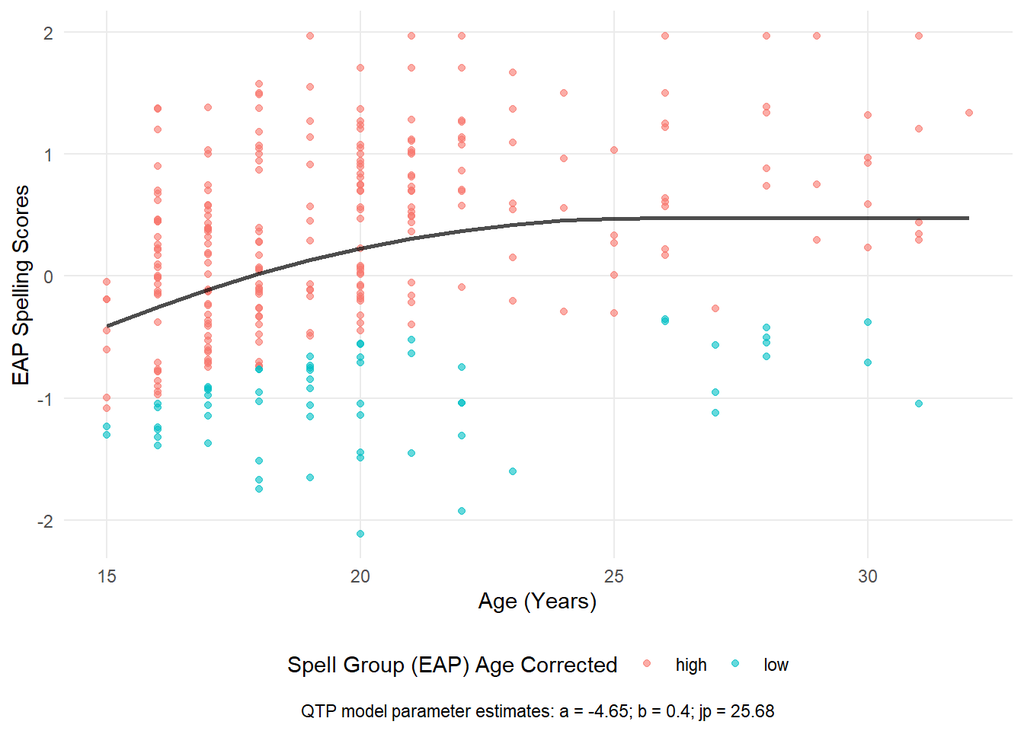

Lastly, we can create a contingency table to see whether or not we now have a better distribution of good and poor spellers across age groups and we can see that we do!

Good vs Poor Spellers Across Age Groups (Age Corrected) Contingency Table

| Age_group | Spell_Group_EAP_corrected |  | Total |  |
| --- | --- | --- | --- | --- |
|  | high | low |  |  |
| 15-17 | 80 84.2 % | 15 15.8 % |  | 95 100 % |
| 17-18 | 33 82.5 % | 7 17.5 % | 40 100 % |  |
| 18-20 | 49 73.1 % | 18 26.9 % | 67 100 % |  |
| 20-22 | 35 81.4 % | 8 18.6 % | 43 100 % |  |
| 22-32 | 45 77.6 % | 13 22.4 % | 58 100 % |  |
| Total | 242 79.9 % | 61 20.1 % | 303 100 % |  |

```r
# Change the working directory
setwd(clean_data_output)

# Save the ARFA data with the IRT scores
saveRDS(comb_dat2, "5_comb_dat.rds")
```